# Data Tidak Stasioner

Author

Gemala Aleida FItri

Published

October 2, 2025

```r
library(ggplot2)
library(tsibble)
library(tseries)
library(MASS)
library(dplyr)
library(forecast)
```

## Tidak Stationer dalam Rataan, Stasioner dalam Ragam .

```r
df <- read.csv("C:/Users/Ainul Hayati/Documents/kuliah/Departemen/Semester 5/Metode Peramalan Deret Waktu/Praktikum MPDW/Telur Ayam Ras.csv")
stas <- df[1:159,]
head(stas)
```

```
        Date Jawa.Barat
1 2022-07-14      27680
2 2022-07-15      27920
3 2022-07-16      27960
4 2022-07-17      27890
5 2022-07-18      27950
6 2022-07-19      28260
```

### Plot *Time Series*

```r
stas <- stas %>%
  mutate(Date = as.Date(Date))
stas_tsibble <- stas %>%
  as_tsibble(index = Date)

plot_stas <- stas |> as_tsibble() |>
  ggplot(aes(x = Date, y = `Jawa.Barat`)) + geom_line() + theme_bw() +
  xlab("Tanggal") + ylab("Harga")
```

```
Using `Date` as index variable.
```

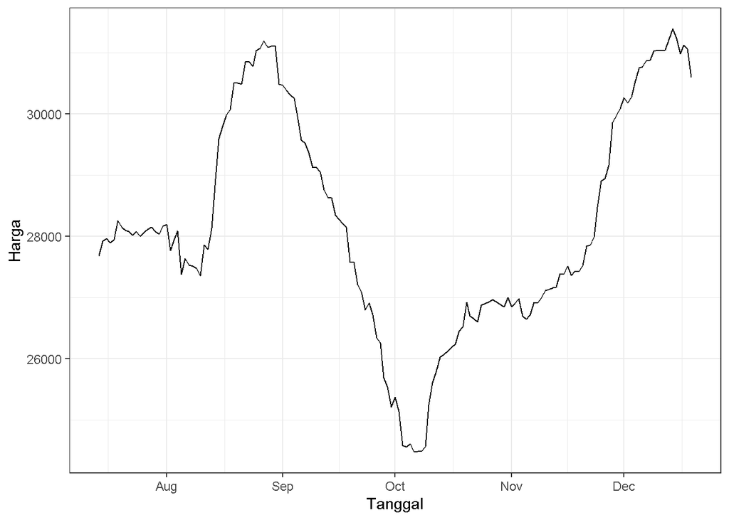

```r
plot_stas
```

```r
mean(stas$Jawa.Barat)
```

```
[1] 28188.43
```

```r
var(stas$Jawa.Barat)
```

```
[1] 3369866
```

```r
N <- nrow(stas)              # jumlah observasi
n_train <- floor(0.8 * N)    # 80% untuk train

# Partisi data
train_data <- stas[1:n_train, ]
test_data  <- stas[(n_train+1):N, ]
```

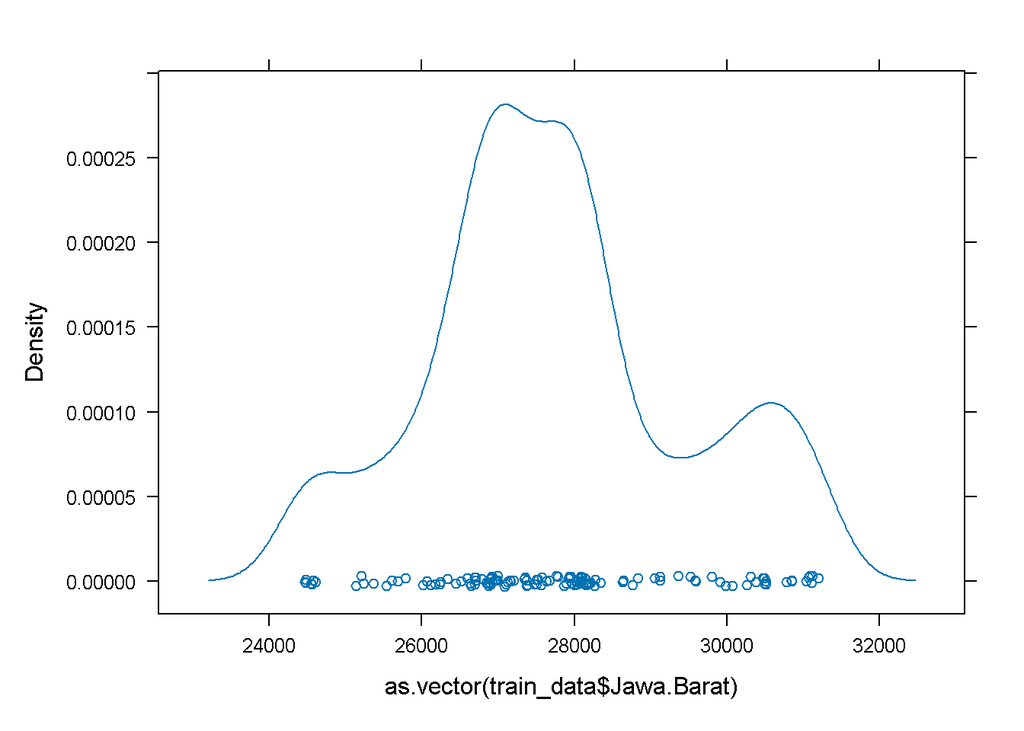

```r
lattice::densityplot(as.vector(train_data$Jawa.Barat))
```

Plot deret waktu di atas menunjukkan bahwa data tidak stasioner dalam rataan, ditandai dengan terdapat dua puncak, artinya ada perubahan rataan dan stasioner dalam ragam, ditandai dengan data berfluktuasi pada rentang yang relatif sama sepanjang waktu.

### Plot ACF

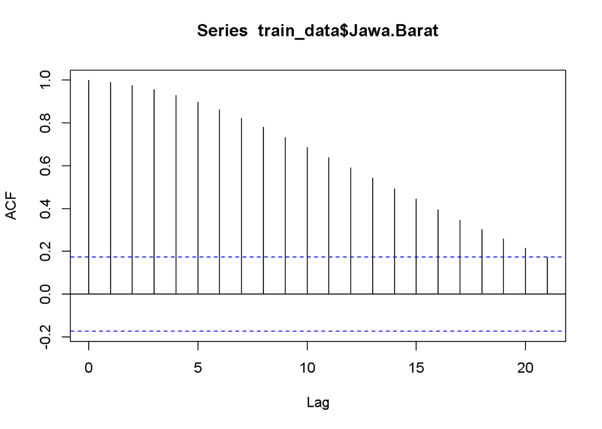

```r
acf(train_data$Jawa.Barat)
```

Berdasarkan plot ACF, terlihat bahwa plot ACF pada data tersebut cenderung *tails off* secara lambat, artinya data tidak stasioner dan berindikasi ada tren.

### Uji ADF

```r
tseries::adf.test(train_data$Jawa.Barat)
```

```
    Augmented Dickey-Fuller Test

data:  train_data$Jawa.Barat
Dickey-Fuller = -2.3135, Lag order = 5, p-value = 0.4462
alternative hypothesis: stationary
```

$H_0$ : Data tidak stasioner dalam rataan $H_1$ : Data stasioner dalam rataan

Berdasarkan uji ADF tersebut, didapat *p-value* sebesar 0.4462 yang lebih besar dari taraf nyata 5% sehingga terima $H_0$ dan menandakan bahwa data **tidak stasioner dalam rataan**. Hal ini sesuai dengan hasil eksplorasi menggunakan plot time series dan plot ACF.

### Plot Box-Cox

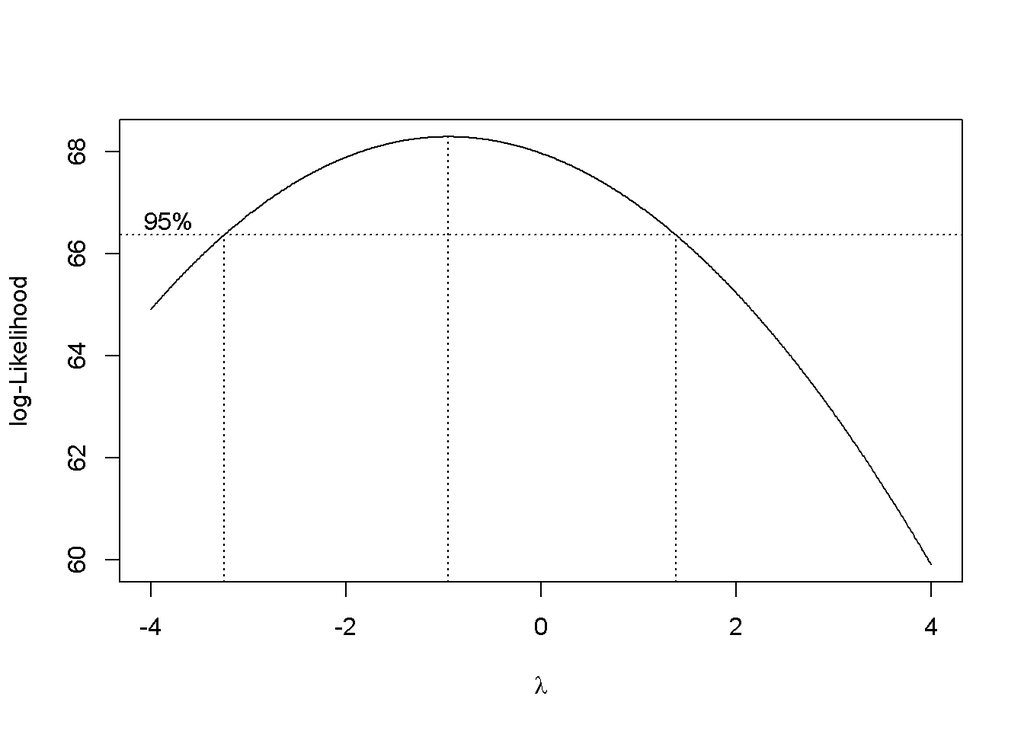

```r
#index <- seq(1:200)

# Box-Cox
bc <- boxcox(
  train_data$Jawa.Barat ~ train_data$Date,
  lambda = seq(-4, 4, by = 0.01)
)
```

```r
# Nilai lambda optimum
lambda <- bc$x[which.max(bc$y)]
lambda
```

```
[1] -0.95
```

```r
# Selang kepercayaan 95% untuk lambda
ci_lambda <- bc$x[bc$y > max(bc$y) - 0.5 * qchisq(0.95, 1)]

# Batas bawah dan batas atas
ci_lower <- min(ci_lambda)
ci_upper <- max(ci_lambda)

c(Batas_Bawah = ci_lower, Batas_Atas = ci_upper)
```

```
Batas_Bawah  Batas_Atas
      -3.25        1.38
```

Gambar di atas menunjukkan nilai λ optimum (rounded value) sebesar **-0.95** dan selang kepercayaan 95% nilai memiliki batas bawah **-3,25** dan batas atas **1,38**. Selang tersebut memuat nilai satu sehingga dapat dikatakan bahwa data bangkitan **stasioner dalam ragam**.

### Differencing

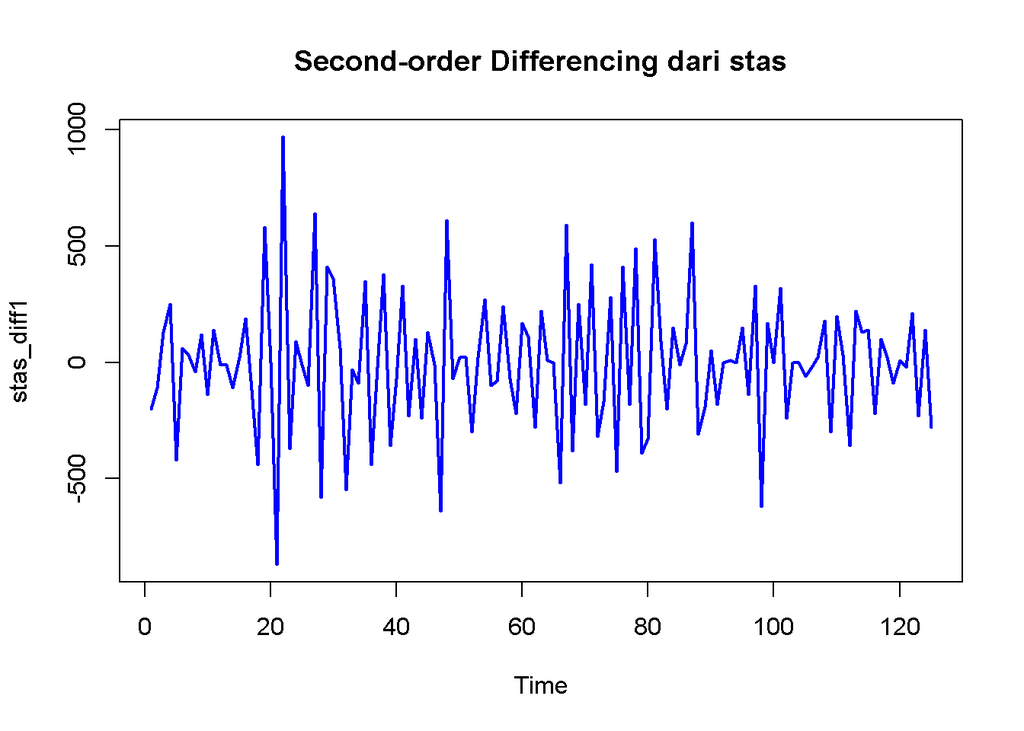

```r
# Differencing kedua pada data uji
stas_diff1 <- diff(train_data$Jawa.Barat, differences = 2)

# Plot hasil differencing
ts.plot(stas_diff1,
        main = "Second-order Differencing dari stas",
        col = "blue", lwd = 2)
```

### Plot ACF

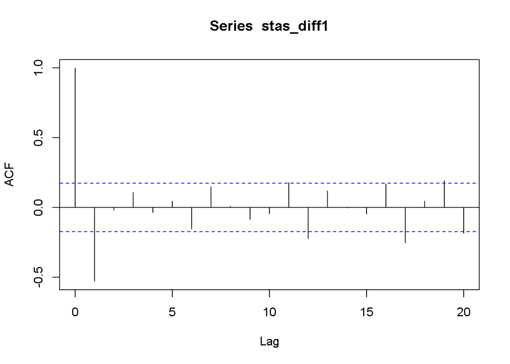

```r
acf(stas_diff1)
```

Berdasarkan plot ACF, terlihat bahwa data stasioner dalam rataan.

### Uji ADF

```r
adf.test(stas_diff1)
```

```
    Augmented Dickey-Fuller Test

data:  stas_diff1
Dickey-Fuller = -6.3993, Lag order = 4, p-value = 0.01
alternative hypothesis: stationary
```

Berdasarkan uji ADF tersebut, didapat *p-value* sebesar 0.01 yang lebih kecil dari taraf nyata 5% sehingga tolak $H_0$ dan menandakan bahwa **data sudah stasioner dalam rataan**. Hal ini sesuai dengan hasil eksplorasi menggunakan plot time series dan plot ACF.

### Pengujian Data Uji

```r
train_ts <- ts(train_data$Jawa.Barat, frequency = 1)
test_ts  <- ts(test_data$Jawa.Barat,
               start = n_train + 1, frequency = 1)

# Fit ARIMA(0,2,1)
fit <- Arima(train_ts, order = c(0,2,1))
summary(fit)
```

```
Series: train_ts
ARIMA(0,2,1)

Coefficients:
          ma1
      -0.7788
s.e.   0.0567

sigma^2 = 49094:  log likelihood = -852.41
AIC=1708.82   AICc=1708.92   BIC=1714.48

Training set error measures:
                    ME     RMSE      MAE          MPE      MAPE      MASE
Training set -4.319056 218.9401 159.6519 -0.008450403 0.5782758 0.9928991
                    ACF1
Training set -0.09557628
```

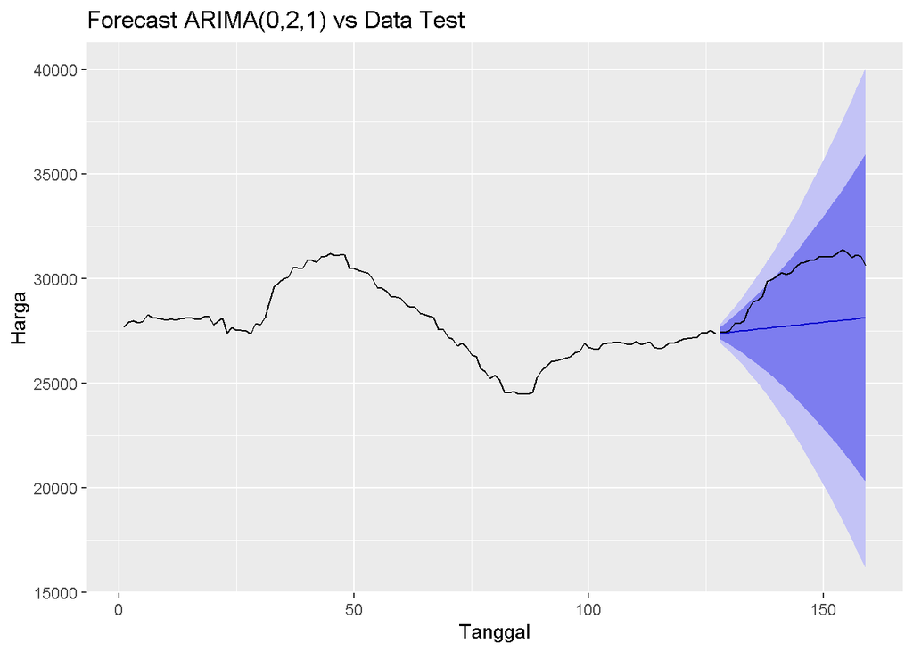

```r
# Forecast sepanjang horizon test
h <- length(test_ts)
fc <- forecast(fit, h = h)

# Plot perbandingan train, forecast, dan test
autoplot(fc) +
  autolayer(test_ts, series = "Test", color = "black") +
  xlab("Tanggal") + ylab("Harga") +
  ggtitle("Forecast ARIMA(0,2,1) vs Data Test")
```

```r
accuracy(fc, test_ts)
```

```
                      ME      RMSE       MAE          MPE      MAPE       MASE
Training set   -4.319056  218.9401  159.6519 -0.008450403 0.5782758  0.9928991
Test set     2178.908795 2441.8408 2178.9088  7.128341120 7.1283411 13.5509629
                    ACF1 Theil's U
Training set -0.09557628        NA
Test set      0.92026454  10.13502
```